# UAHDataScienceUC: A Comprehensive Guide to Clustering Algorithms

## Genetic K-Means

This algorithm combines traditional k-means with genetic algorithm concepts for potentially better cluster optimization.

```r
result <- genetic_kmeans(
  data,
  k = 3,
  population_size = 10,
  mut_probability = 0.5,
  max_generations = 10,
  learn = TRUE
)
```

```
## ________________________________________________________________________________
```

```
## EXPLANATION:
```

```
## The Genetic K-Means algorithm combines the K-Means clustering method with geneti
```

```
## c algorithm concepts.
```

```
## It follows these main steps:
```

```
## 1. Initialize a population of random cluster assignments
```

```
## 2. Evaluate the fitness of each individual based on within-cluster variation
```

```
## 3. Select parents for the next generation based on fitness
```

```
## 4. Apply mutation and crossover to create new individuals
```

```
## 5. Repeat steps 2-4 for a specified number of generations
```

```
## Press [enter] to continue
```

```
## ________________________________________________________________________________
```

```
## INITIALIZATION:
```

```
## A population of 10 individuals has been randomly initialized.
```

```
## Each individual represents a possible clustering solution.
```

```
## Here's a sample of the initial population (first 5 individuals, first 10 data po
```

```
## ints):
```

```
##      [,1] [,2] [,3] [,4] [,5] [,6] [,7] [,8] [,9] [,10]
## [1,]    3    3    2    1    3    2    3    1    2     1
## [2,]    1    1    3    3    2    3    2    3    1     2
## [3,]    3    1    2    1    2    1    3    2    1     3
## [4,]    1    1    3    1    2    2    3    2    2     3
## [5,]    1    3    3    2    1    3    2    3    1     2
```

```
## Press [enter] to continue
```

```
## INITIAL FITNESS:
```

```
## Best fitness: 4.74
```

```
## Average fitness: 2.39
```

```
## Press [enter] to continue
```

```
## ________________________________________________________________________________
```

```
## GENERATION: 1
```

```
## SELECTION:
```

```
## Parents for the next generation are selected based on their fitness.
```

```
## Selected parent (first 10 data points):
```

```
##  [1] 1 1 3 2 1 2 3 2 3 3
```

```
## Press [enter] to continue
```

```
## MUTATION:
```

```
## Random mutations are applied to the chromosomes with probability0.50
```

```
## Sample of mutated population (first 5 individuals, first 10 data points):
```

```
##      [,1] [,2] [,3] [,4] [,5] [,6] [,7] [,8] [,9] [,10]
## [1,]    1    3    3    2    1    2    3    3    3     3
## [2,]    1    2    2    2    1    1    2    2    3     3
## [3,]    1    1    3    2    2    1    2    2    3     3
## [4,]    1    2    2    2    1    2    3    2    3     2
## [5,]    1    2    3    2    1    2    3    2    3     3
```

```
## Press [enter] to continue
```

```
## CROSSOVER:
```

```
## K-Means Operator (KMO) is applied as a form of crossover.
```

```
## This reassigns each point to its nearest center.
```

```
## Sample of population after crossover (first 5 individuals, first 10 data points)
```

```
## :
```

```
##      [,1] [,2] [,3] [,4] [,5] [,6] [,7] [,8] [,9] [,10]
## [1,]    1    3    3    2    2    2    3    2    3     3
## [2,]    1    3    3    1    2    2    3    2    3     3
## [3,]    1    3    3    2    2    2    3    2    3     3
## [4,]    1    3    3    2    2    2    3    2    3     3
## [5,]    1    3    3    2    2    2    3    2    3     3
```

```
## Press [enter] to continue
```

```
## FITNESS EVALUATION:
```

```
## The fitness of each individual is calculated based on within-cluster variation.
```

```
## Best fitness in this generation: 2.41
```

```
## Average fitness: 2.17
```

```
## Total Within-Cluster Variation of best solution: 0.36
```

```
## Press [enter] to continue
```

```
## ________________________________________________________________________________
```

```
## GENERATION: 2
```

```
## SELECTION:
```

```
## Parents for the next generation are selected based on their fitness.
```

```
## Selected parent (first 10 data points):
```

```
##  [1] 1 3 3 2 2 2 3 2 3 3
```

```
## Press [enter] to continue
```

```
## MUTATION:
```

```
## Random mutations are applied to the chromosomes with probability0.50
```

```
## Sample of mutated population (first 5 individuals, first 10 data points):
```

```
##      [,1] [,2] [,3] [,4] [,5] [,6] [,7] [,8] [,9] [,10]
## [1,]    1    3    3    3    2    2    2    2    3     3
## [2,]    1    3    3    2    2    2    1    2    3     3
## [3,]    1    3    2    3    2    2    3    2    3     3
## [4,]    1    3    3    2    1    2    3    2    2     2
## [5,]    1    3    3    2    2    2    3    3    3     2
```

```
## Press [enter] to continue
```

```
## CROSSOVER:
```

```
## K-Means Operator (KMO) is applied as a form of crossover.
```

```
## This reassigns each point to its nearest center.
```

```
## Sample of population after crossover (first 5 individuals, first 10 data points)
```

```
## :
```

```
##      [,1] [,2] [,3] [,4] [,5] [,6] [,7] [,8] [,9] [,10]
## [1,]    1    3    3    2    2    2    3    2    3     3
## [2,]    1    3    3    2    2    2    3    2    3     3
## [3,]    1    3    3    2    2    2    3    2    3     3
## [4,]    1    3    3    2    2    2    3    2    3     3
## [5,]    1    3    3    2    2    2    3    2    3     3
```

```
## Press [enter] to continue
```

```
## FITNESS EVALUATION:
```

```
## The fitness of each individual is calculated based on within-cluster variation.
```

```
## Best fitness in this generation: 0.00
```

```
## Average fitness: 0.00
```

```
## Total Within-Cluster Variation of best solution: 0.36
```

```
## Press [enter] to continue
```

```
## ________________________________________________________________________________
```

```
## GENERATION: 3
```

```
## SELECTION:
```

```
## Parents for the next generation are selected based on their fitness.
```

```
## Selected parent (first 10 data points):
```

```
##  [1] 1 3 3 2 2 2 3 2 3 3
```

```
## Press [enter] to continue
```

```
## MUTATION:
```

```
## Random mutations are applied to the chromosomes with probability0.50
```

```
## Sample of mutated population (first 5 individuals, first 10 data points):
```

```
##      [,1] [,2] [,3] [,4] [,5] [,6] [,7] [,8] [,9] [,10]
## [1,]    1    3    3    2    2    3    3    2    2     3
## [2,]    1    2    3    2    2    3    1    3    3     1
## [3,]    1    2    3    2    2    2    3    2    3     3
## [4,]    1    2    3    3    2    2    3    2    3     1
## [5,]    1    3    3    2    2    2    3    3    3     3
```

```
## Press [enter] to continue
```

```
## CROSSOVER:
```

```
## K-Means Operator (KMO) is applied as a form of crossover.
```

```
## This reassigns each point to its nearest center.
```

```
## Sample of population after crossover (first 5 individuals, first 10 data points)
```

```
## :
```

```
##      [,1] [,2] [,3] [,4] [,5] [,6] [,7] [,8] [,9] [,10]
## [1,]    1    3    3    2    2    2    3    2    3     3
## [2,]    1    3    3    2    2    2    3    2    3     3
## [3,]    1    3    3    2    2    2    3    2    3     3
## [4,]    1    3    3    2    2    2    3    2    3     3
## [5,]    1    3    3    2    2    2    3    2    3     3
```

```
## Press [enter] to continue
```

```
## FITNESS EVALUATION:
```

```
## The fitness of each individual is calculated based on within-cluster variation.
```

```
## Best fitness in this generation: 3.43
```

```
## Average fitness: 3.09
```

```
## Total Within-Cluster Variation of best solution: 0.36
```

```
## Press [enter] to continue
```

```
## ________________________________________________________________________________
```

```
## GENERATION: 4
```

```
## SELECTION:
```

```
## Parents for the next generation are selected based on their fitness.
```

```
## Selected parent (first 10 data points):
```

```
##  [1] 1 3 3 2 2 2 3 2 3 3
```

```
## Press [enter] to continue
```

```
## MUTATION:
```

```
## Random mutations are applied to the chromosomes with probability0.50
```

```
## Sample of mutated population (first 5 individuals, first 10 data points):
```

```
##      [,1] [,2] [,3] [,4] [,5] [,6] [,7] [,8] [,9] [,10]
## [1,]    1    3    1    2    2    2    3    3    3     3
## [2,]    1    3    2    2    1    1    3    2    3     3
## [3,]    3    2    3    2    1    2    2    2    3     3
## [4,]    1    2    2    2    2    2    3    2    3     3
## [5,]    3    3    3    2    2    2    3    2    3     1
```

```
## Press [enter] to continue
```

```
## CROSSOVER:
```

```
## K-Means Operator (KMO) is applied as a form of crossover.
```

```
## This reassigns each point to its nearest center.
```

```
## Sample of population after crossover (first 5 individuals, first 10 data points)
```

```
## :
```

```
##      [,1] [,2] [,3] [,4] [,5] [,6] [,7] [,8] [,9] [,10]
## [1,]    1    3    3    2    2    2    3    2    3     3
## [2,]    1    3    3    2    2    2    3    2    3     3
## [3,]    3    2    2    1    1    1    2    1    2     3
## [4,]    1    3    3    2    2    2    3    2    3     3
## [5,]    3    1    3    2    2    2    1    3    1     1
```

```
## Press [enter] to continue
```

```
## FITNESS EVALUATION:
```

```
## The fitness of each individual is calculated based on within-cluster variation.
```

```
## Best fitness in this generation: 7.46
```

```
## Average fitness: 5.72
```

```
## Total Within-Cluster Variation of best solution: 0.36
```

```
## Press [enter] to continue
```

```
## ________________________________________________________________________________
```

```
## GENERATION: 5
```

```
## SELECTION:
```

```
## Parents for the next generation are selected based on their fitness.
```

```
## Selected parent (first 10 data points):
```

```
##  [1] 1 3 3 2 2 2 3 2 3 3
```

```
## Press [enter] to continue
```

```
## MUTATION:
```

```
## Random mutations are applied to the chromosomes with probability0.50
```

```
## Sample of mutated population (first 5 individuals, first 10 data points):
```

```
##      [,1] [,2] [,3] [,4] [,5] [,6] [,7] [,8] [,9] [,10]
## [1,]    1    3    2    2    2    2    3    2    3     3
## [2,]    1    2    3    1    3    2    3    2    3     2
## [3,]    1    3    3    2    2    3    1    3    3     3
## [4,]    3    3    1    1    2    1    2    2    3     2
## [5,]    1    3    3    1    2    3    1    2    3     3
```

```
## Press [enter] to continue
```

```
## CROSSOVER:
```

```
## K-Means Operator (KMO) is applied as a form of crossover.
```

```
## This reassigns each point to its nearest center.
```

```
## Sample of population after crossover (first 5 individuals, first 10 data points)
```

```
## :
```

```
##      [,1] [,2] [,3] [,4] [,5] [,6] [,7] [,8] [,9] [,10]
## [1,]    1    3    3    2    2    2    3    2    3     3
## [2,]    1    3    3    2    2    2    3    2    3     3
## [3,]    1    3    3    2    2    2    3    2    3     3
## [4,]    3    2    2    1    1    1    2    1    2     2
## [5,]    1    3    3    2    2    2    3    2    3     3
```

```
## Press [enter] to continue
```

```
## FITNESS EVALUATION:
```

```
## The fitness of each individual is calculated based on within-cluster variation.
```

```
## Best fitness in this generation: 3.45
```

```
## Average fitness: 3.10
```

```
## Total Within-Cluster Variation of best solution: 0.36
```

```
## Press [enter] to continue
```

```
## ________________________________________________________________________________
```

```
## GENERATION: 6
```

```
## SELECTION:
```

```
## Parents for the next generation are selected based on their fitness.
```

```
## Selected parent (first 10 data points):
```

```
##  [1] 1 3 3 2 2 2 3 2 3 3
```

```
## Press [enter] to continue
```

```
## MUTATION:
```

```
## Random mutations are applied to the chromosomes with probability0.50
```

```
## Sample of mutated population (first 5 individuals, first 10 data points):
```

```
##      [,1] [,2] [,3] [,4] [,5] [,6] [,7] [,8] [,9] [,10]
## [1,]    2    3    2    2    2    2    1    2    3     3
## [2,]    1    3    3    2    2    2    1    2    3     1
## [3,]    1    2    3    1    2    2    1    2    3     2
## [4,]    1    3    2    2    2    1    3    2    1     3
## [5,]    1    3    3    2    2    3    3    2    2     3
```

```
## Press [enter] to continue
```

```
## CROSSOVER:
```

```
## K-Means Operator (KMO) is applied as a form of crossover.
```

```
## This reassigns each point to its nearest center.
```

```
## Sample of population after crossover (first 5 individuals, first 10 data points)
```

```
## :
```

```
##      [,1] [,2] [,3] [,4] [,5] [,6] [,7] [,8] [,9] [,10]
## [1,]    2    3    3    2    2    2    1    2    3     3
## [2,]    1    3    3    2    2    2    3    2    3     3
## [3,]    1    3    3    2    2    2    3    2    3     3
## [4,]    1    3    3    2    2    2    3    2    3     3
## [5,]    1    3    3    2    2    2    3    2    3     3
```

```
## Press [enter] to continue
```

```
## FITNESS EVALUATION:
```

```
## The fitness of each individual is calculated based on within-cluster variation.
```

```
## Best fitness in this generation: 4.25
```

```
## Average fitness: 3.83
```

```
## Total Within-Cluster Variation of best solution: 0.36
```

```
## Press [enter] to continue
```

```
## ________________________________________________________________________________
```

```
## GENERATION: 7
```

```
## SELECTION:
```

```
## Parents for the next generation are selected based on their fitness.
```

```
## Selected parent (first 10 data points):
```

```
##  [1] 1 3 3 2 2 2 3 2 3 3
```

```
## Press [enter] to continue
```

```
## MUTATION:
```

```
## Random mutations are applied to the chromosomes with probability0.50
```

```
## Sample of mutated population (first 5 individuals, first 10 data points):
```

```
##      [,1] [,2] [,3] [,4] [,5] [,6] [,7] [,8] [,9] [,10]
## [1,]    2    3    3    2    3    1    1    2    1     3
## [2,]    1    3    3    1    2    2    3    2    3     1
## [3,]    1    1    3    2    2    2    2    2    1     3
## [4,]    1    3    3    2    3    3    1    2    3     3
## [5,]    3    3    2    2    2    1    1    2    2     2
```

```
## Press [enter] to continue
```

```
## CROSSOVER:
```

```
## K-Means Operator (KMO) is applied as a form of crossover.
```

```
## This reassigns each point to its nearest center.
```

```
## Sample of population after crossover (first 5 individuals, first 10 data points)
```

```
## :
```

```
##      [,1] [,2] [,3] [,4] [,5] [,6] [,7] [,8] [,9] [,10]
## [1,]    2    1    1    2    3    3    1    3    1     1
## [2,]    1    3    3    2    2    2    3    2    3     3
## [3,]    1    3    3    2    2    2    3    2    3     3
## [4,]    1    3    3    2    2    2    3    2    3     3
## [5,]    3    1    1    2    2    2    1    2    1     1
```

```
## Press [enter] to continue
```

```
## FITNESS EVALUATION:
```

```
## The fitness of each individual is calculated based on within-cluster variation.
```

```
## Best fitness in this generation: 3.43
```

```
## Average fitness: 2.77
```

```
## Total Within-Cluster Variation of best solution: 0.36
```

```
## Press [enter] to continue
```

```
## ________________________________________________________________________________
```

```
## GENERATION: 8
```

```
## SELECTION:
```

```
## Parents for the next generation are selected based on their fitness.
```

```
## Selected parent (first 10 data points):
```

```
##  [1] 1 3 3 2 2 2 3 2 3 3
```

```
## Press [enter] to continue
```

```
## MUTATION:
```

```
## Random mutations are applied to the chromosomes with probability0.50
```

```
## Sample of mutated population (first 5 individuals, first 10 data points):
```

```
##      [,1] [,2] [,3] [,4] [,5] [,6] [,7] [,8] [,9] [,10]
## [1,]    1    3    3    2    2    2    3    2    3     2
## [2,]    1    2    2    2    2    2    3    2    3     3
## [3,]    1    2    3    2    3    2    3    1    2     3
## [4,]    1    3    3    1    2    2    2    2    3     1
## [5,]    1    3    2    2    2    3    3    3    2     3
```

```
## Press [enter] to continue
```

```
## CROSSOVER:
```

```
## K-Means Operator (KMO) is applied as a form of crossover.
```

```
## This reassigns each point to its nearest center.
```

```
## Sample of population after crossover (first 5 individuals, first 10 data points)
```

```
## :
```

```
##      [,1] [,2] [,3] [,4] [,5] [,6] [,7] [,8] [,9] [,10]
## [1,]    1    3    3    2    2    2    3    2    3     3
## [2,]    1    3    3    2    2    2    3    2    3     3
## [3,]    1    3    3    2    2    2    3    2    3     3
## [4,]    1    3    3    2    2    2    3    2    3     3
## [5,]    1    3    3    2    2    2    3    2    3     3
```

```
## Press [enter] to continue
```

```
## FITNESS EVALUATION:
```

```
## The fitness of each individual is calculated based on within-cluster variation.
```

```
## Best fitness in this generation: 0.00
```

```
## Average fitness: 0.00
```

```
## Total Within-Cluster Variation of best solution: 0.36
```

```
## Press [enter] to continue
```

```
## ________________________________________________________________________________
```

```
## GENERATION: 9
```

```
## SELECTION:
```

```
## Parents for the next generation are selected based on their fitness.
```

```
## Selected parent (first 10 data points):
```

```
##  [1] 1 3 3 2 2 2 3 2 3 3
```

```
## Press [enter] to continue
```

```
## MUTATION:
```

```
## Random mutations are applied to the chromosomes with probability0.50
```

```
## Sample of mutated population (first 5 individuals, first 10 data points):
```

```
##      [,1] [,2] [,3] [,4] [,5] [,6] [,7] [,8] [,9] [,10]
## [1,]    2    3    3    2    3    1    3    2    1     1
## [2,]    1    3    2    2    2    3    3    2    3     3
## [3,]    1    3    3    2    3    2    3    2    3     3
## [4,]    1    3    3    2    2    2    3    1    3     3
## [5,]    1    3    1    2    2    3    3    2    3     3
```

```
## Press [enter] to continue
```

```
## CROSSOVER:
```

```
## K-Means Operator (KMO) is applied as a form of crossover.
```

```
## This reassigns each point to its nearest center.
```

```
## Sample of population after crossover (first 5 individuals, first 10 data points)
```

```
## :
```

```
##      [,1] [,2] [,3] [,4] [,5] [,6] [,7] [,8] [,9] [,10]
## [1,]    2    3    3    2    3    1    3    2    3     1
## [2,]    1    3    3    2    2    2    3    2    3     3
## [3,]    1    3    3    2    2    2    3    2    3     3
## [4,]    1    3    3    2    2    2    3    2    3     3
## [5,]    1    3    3    2    2    2    3    2    3     3
```

```
## Press [enter] to continue
```

```
## FITNESS EVALUATION:
```

```
## The fitness of each individual is calculated based on within-cluster variation.
```

```
## Best fitness in this generation: 5.35
```

```
## Average fitness: 4.38
```

```
## Total Within-Cluster Variation of best solution: 0.36
```

```
## Press [enter] to continue
```

```
## ________________________________________________________________________________
```

```
## GENERATION: 10
```

```
## SELECTION:
```

```
## Parents for the next generation are selected based on their fitness.
```

```
## Selected parent (first 10 data points):
```

```
##  [1] 1 3 3 2 2 2 3 2 3 3
```

```
## Press [enter] to continue
```

```
## MUTATION:
```

```
## Random mutations are applied to the chromosomes with probability0.50
```

```
## Sample of mutated population (first 5 individuals, first 10 data points):
```

```
##      [,1] [,2] [,3] [,4] [,5] [,6] [,7] [,8] [,9] [,10]
## [1,]    1    2    3    2    1    2    3    2    3     1
## [2,]    1    3    2    2    2    2    3    2    3     3
## [3,]    3    1    2    3    1    2    3    2    1     3
## [4,]    1    3    3    2    3    2    3    2    2     2
## [5,]    1    2    3    2    2    2    3    2    2     2
```

```
## Press [enter] to continue
```

```
## CROSSOVER:
```

```
## K-Means Operator (KMO) is applied as a form of crossover.
```

```
## This reassigns each point to its nearest center.
```

```
## Sample of population after crossover (first 5 individuals, first 10 data points)
```

```
## :
```

```
##      [,1] [,2] [,3] [,4] [,5] [,6] [,7] [,8] [,9] [,10]
## [1,]    1    3    3    2    2    2    3    2    3     3
## [2,]    1    3    3    2    2    2    3    2    3     3
## [3,]    3    1    1    2    2    2    1    2    1     1
## [4,]    1    3    3    2    2    2    3    2    3     3
## [5,]    1    3    3    2    2    2    3    2    3     3
```

```
## Press [enter] to continue
```

```
## FITNESS EVALUATION:
```

```
## The fitness of each individual is calculated based on within-cluster variation.
```

```
## Best fitness in this generation: 2.45
```

```
## Average fitness: 2.21
```

```
## Total Within-Cluster Variation of best solution: 0.36
```

```
## Press [enter] to continue
```

```
## ________________________________________________________________________________
```

```
## FINAL RESULTS:
```

```
## Number of clusters: 3
```

```
## Total sum of squares: 11.68
```

```
## Total within-cluster sum of squares: 0.36
```

```
## Between-cluster sum of squares: 11.31
```

```
## Cluster sizes:
```

```
## [1] 1 4 5
```

```
## Final cluster centers:
```

```
##   [,1]    [,2]
## 1 "-1.58" "-1.29"
## 2 "0.74"  "0.12"
## 3 "0.71"  "1.24"
```

```
## Generating plot of clustering results...
```

```
## Plot generated. Check the graphics device.
```

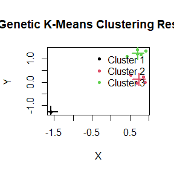

## Correlation Clustering

Correlation clustering performs hierarchical clustering by analyzing relationships between data points and a target, with support for weighted features.

```r
# Create sample data
data <- matrix(c(1,2,1,4,5,1,8,2,9,6,3,5,8,5,4), ncol=3)
dataFrame <- data.frame(data)
target <- c(1,2,3)
weights <- c(0.1, 0.6, 0.3)

# Perform correlation clustering
result <- correlation_clustering(
    dataFrame,
    target = target,
    weight = weights,
    distance_method = "euclidean",
    normalize = TRUE,
    learn = TRUE
)
```

```
## EXPLANATION:
```

```
## The Correlation Hierarchical Clustering algorithm is a classification technique
```

```
## that:
```

```
##     1. Initializes a cluster for each data point
```

```
##     2. Calculates distances between clusters and a given target
```

```
##     3. Applies weights to achieve weighted results
```

```
## Due to normalize = TRUE, weights will be normalized to [0,1] range
```

```
## ________________________________________________________________________________
```

```
## WEIGHT NORMALIZATION:
```

```
## Initial weights:
```

```
##   Weight 1: 0.100000
```

```
##   Weight 2: 0.600000
```

```
##   Weight 3: 0.300000
```

```
## No weights provided
```

```
## Initializing 3 weights with value 1
```

```
## Normalizing weights:
```

```
## Total sum: 1.000000
```

```
## Formula: weight[i] = weight[i] / total
```

```
##
##  These are the new weights:
```

```
##   Weight 1: 0.100000
```

```
##   Weight 2: 0.600000
```

```
##   Weight 3: 0.300000
```

```
## ________________________________________________________________________________
```

```
## WEIGHTS:
```

```
## The following weights will be used:
```

```
## [1] 0.1 0.6 0.3
```

```
## Euclidean Distance Formula:
```

```
## d(x,y) = √(∑1ⁿ (xᵢ - yᵢ)²)
```

```
## This distance metric will be used to:
```

```
##     - Calculate distances between each cluster and the target
```

```
##     - Sort clusters by their similarity to the target
```

```
## DATA INITIALIZATION:
```

```
## Input data:
```

```
##   X1 X2 X3
## 1  1  1  3
## 2  2  8  5
## 3  1  2  8
## 4  4  9  5
## 5  5  6  4
```

```
## Each cluster is initialized as a matrix with one row and the same columns as the
```

```
##  input data
```

```
## Initialized clusters:
```

```
## [[1]]
##      [,1] [,2] [,3]
## [1,]    1    1    3
##
## [[2]]
##      [,1] [,2] [,3]
## [1,]    2    8    5
##
## [[3]]
##      [,1] [,2] [,3]
## [1,]    1    2    8
##
## [[4]]
##      [,1] [,2] [,3]
## [1,]    4    9    5
##
## [[5]]
##      [,1] [,2] [,3]
## [1,]    5    6    4
```

```
## ________________________________________________________________________________
```

```
## TARGET INITIALIZATION:
```

```
## Input target:
```

```
## [1] 1 2 3
```

```
## [1] 1 2 3
```

```
## Converting vector target to matrix format
```

```
## Validating target dimensions:
```

```
## Target has one row
```

```
## Target has same number of columns as input data
```

```
## Final target:
```

```
##      [,1] [,2] [,3]
## [1,]    1    2    3
```

```
## ________________________________________________________________________________
```

```
## INITIALIZATION:
```

```
## Initialized data:
```

```
## [[1]]
##      [,1] [,2] [,3]
## [1,]    1    1    3
##
## [[2]]
##      [,1] [,2] [,3]
## [1,]    2    8    5
##
## [[3]]
##      [,1] [,2] [,3]
## [1,]    1    2    8
##
## [[4]]
##      [,1] [,2] [,3]
## [1,]    4    9    5
##
## [[5]]
##      [,1] [,2] [,3]
## [1,]    5    6    4
```

```
## Initialized target:
```

```
##      [,1] [,2] [,3]
## [1,]    1    2    3
```

```
## ________________________________________________________________________________
```

```
## DISTANCE CALCULATION:
```

```
## Calculating distances between clusters and target using euclidean distance
```

```
## ________________________________________________________________________________
```

```
## DISTANCES:
```

```
## Calculated distances:
```

```
## [1] 1.000000 6.403124 5.000000 7.874008 5.744563
```

```
## Sorted distances:
```

```
## [1] 1.000000 5.000000 5.744563 6.403124 7.874008
```

```
##
##  Then, using sorted distances, the function order the clusters.
##
```

```
## ________________________________________________________________________________
```

```
## RESULTS:
```

```
## Final sorted distances:
```

```
##   cluster sortedDistances
## 1       1        1.000000
## 2       3        5.000000
## 3       5        5.744563
## 4       2        6.403124
## 5       4        7.874008
```

```
## Final sorted clusters:
```

```
##   cluster X1 X2 X3
## 1       1  1  1  3
## 2       3  1  2  8
## 3       5  5  6  4
## 4       2  2  8  5
## 5       4  4  9  5
```

```
## Dendrogram visualization:
```

```
## ________________________________________________________________________________
```

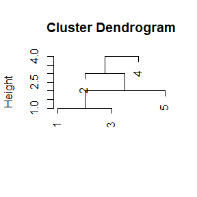

## Distances

The package supports various distance metrics for algorithms like agglomerative clustering and correlation clustering, the available metrics are: euclidean distance, manhattan distance, canberra distance and chebyshev distance.

You can specify these in algorithms that accept a distance parameter:

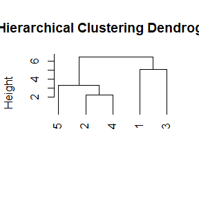

```
## Cluster method   : single
## Distance         : euclidean
## Number of objects: 5
```

```r
# Using different distance metrics
agglomerative_clustering(data, distance_method = "euclidean")
```

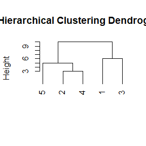

```
## Cluster method   : single
## Distance         : manhattan
## Number of objects: 5
```

```r
agglomerative_clustering(data, distance_method = "manhattan")
```

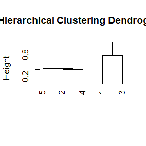

```
## Cluster method   : single
## Distance         : canberra
## Number of objects: 5
```

```r
agglomerative_clustering(data, distance_method = "canberra")
```

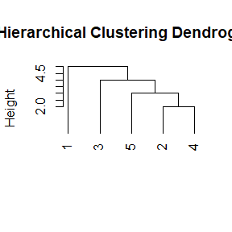

```
## Cluster method   : single
## Distance         : maximum
## Number of objects: 5
```

```r
agglomerative_clustering(data, distance_method = "chebyshev")
```